# Coding Open-Ended Survey Text Without Leaving Stata

[figure not shown]

**Scan for the package,**  
**the do-file, and this poster**

# Coding Open-Ended Survey Text Without Leaving Stata: the `catllm` Package for LLM-Assisted Content Coding

Chris Soria<sup>1</sup>

<sup>1</sup>Department of Demography, University of California, Berkeley

[figure not shown]

[figure not shown]

## Abstract

Open-ended survey items capture what closed-ended items cannot, and are routinely dropped from analysis because hand-coding them does not scale. `catllm` is a Stata command that codes free-text responses with large language models and returns ordinary Stata indicator variables. It wraps a Python backend (`cat-stack`) behind five verbs: `extract`/`explore` find categories, `classify` applies them, and `summarize`/`setup` close the loop, across eight providers from OpenAI and Anthropic to fully local Ollama. Tested on multi-label, multi-class items, proprietary models agree with human coders on **97%** of straightforward items and **88–91%** of complex interpretive ones. Models tend to over-classify; three frontier-open models under unanimous voting correct for it, reaching **0.85** precision against Claude Fable 5’s **0.78** at little cost in recall: a more balanced classification.

## The Problem

- Researchers already use LLMs to code open-ended text, but little guidance exists for keeping classifications aligned with intended meaning without skewing conclusions.
- Model choice is often arbitrary. Researchers overpay for models that excel at general tasks, which rarely predicts coding accuracy.
- **Over-classification** is the dominant error: with several categories per response, models tend to assign labels too liberally, especially on ambiguous text. Recall looks fine; precision does not.
- Doing this from Stata usually means exporting to CSV, scripting in Python, and re-merging, which loses the audit trail that makes coding reproducible.
- **Aim:** put the whole loop inside Stata, with evidence-based levers on accuracy and over-classification: category definitions, model choice, and cross-provider unanimous consensus.

## The Pipeline

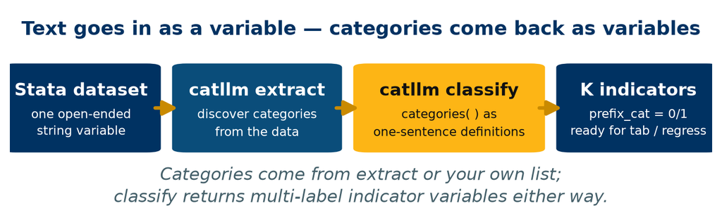

`generate()` is a prefix, not a variable name: a five-category scheme returns five 0/1 byte variables. `extract`’s specificity, iteration count, and category limit are tunable, so discovery matches the research question instead of a fixed default.

## One Command

```stata
catllm classify response,                           ///
    categories(                                     ///
      "Housing cost: Moved over rent, a mortgage, or affordability." ///
      "Employment: Moved for a job, a transfer, or school."          ///
      "Family: Moved for caregiving or to be near relatives."        ///
      "Other: Does not fit any of the above categories.")            ///
    apikey($ANTHROPIC_API_KEY)                      ///
    model("claude-fable-5-1")                       ///
    generate(reason)

tab1 reason_*
regress reason_Housing_cost age female
```

Each category is a full sentence and `Other` is explicit. `catllm` warns on terse labels and offers to add a missing `Other` before coding: without a catch-all, the model must guess on responses that fit nothing. `$ANTHROPIC_API_KEY` is a Stata global, set once with `global ANTHROPIC_API_KEY : env ANTHROPIC_API_KEY`.

## References

Soria (2026). *CatLLM: A Python package for generating, assigning, and scoring open-ended survey data and images.* | Soria (2026). *High agreement, different stories.* | Soria (2026). *Model diversity over model size.* | Bojic et al. (2025). *Comparing LLM and human annotators.* | Wei et al. (2023). *Chain-of-thought prompting.* | Dhuliawala et al. (2023). *Chain-of-verification.* | Zheng et al. (2024). *Step-back prompting.*

## Accuracy Against Human Coders

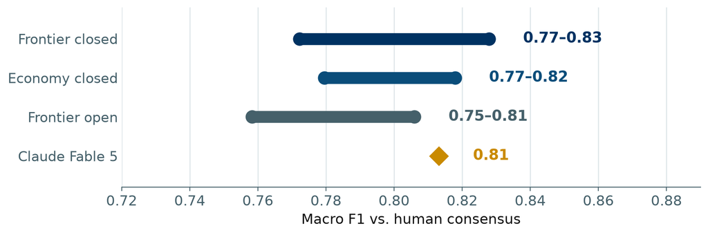

UC Berkeley Social Networks Study validation: macro F1 against human consensus, averaged across three survey questions so no single question dominates. Frontier-closed, economy-closed, and frontier-open tiers overlap closely; Claude Fable 5, shown individually, lands in line with the top cloud tiers. Ranges span the models within each tier.

## What Moves Accuracy

- **Descriptive categories.** Writing each category as a sentence beats one-word labels on every model tested; `catllm` checks the scheme for terse labels and a missing `Other` before any response is coded.
- **Ensembles, where they pay.** Unanimous voting over diverse models lifts precision most on interpretive categories and buys little on clear ones; `consensus()` plus per-response agreement scores let you apply it where it helps.
- **Minimal prompting by default.** Chain-of-thought, step-back, and expert-persona prompts add tokens without improving survey coding in our tests, so they are opt-in flags, not defaults: cheaper runs, same accuracy.
- **Every tier through one command.** Frontier, economy, open-weight, and local models across eight providers are a `model()` argument away, so switching tiers is a parameter change, not a rewrite.

## Local Model Spread

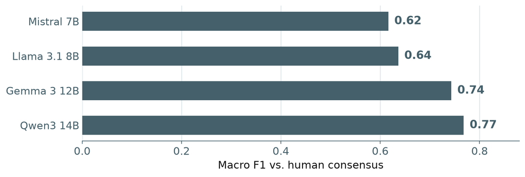

Same macro F1 against human consensus as the cloud tiers, for the four laptop-scale Ollama models. The spread here (0.62–0.77) is about double the cloud tiers’ (0.76–0.83): picking well matters far more once you’re local.

## Choosing a Route

| Route | Cost | Speed | Error profile | Data leaves machine |
| --- | --- | --- | --- | --- |
| Frontier proprietary | High | Slow | Tends to over-classify | Yes |
| Small proprietary | Low | Fast | Tends to over-classify | Yes |
| Multi-vendor unanimous ensemble | Sum of parts | Slowest member | Conservative | Unless all local |
| Local open-weight (Ollama) | $0 | Hardware-bound | Varies by model | No |

Single models of every size tend to assign categories too liberally. A unanimous ensemble of three diverse models corrects for it: pick it when a false positive costs more than a missed code, and when the categories are interpretive, where the precision gain is largest. For restricted-use data under an IRB or data-use agreement, the local route is often the only admissible one, and `catllm` treats it as a first-class route: any Ollama model goes in `model()`, the server starts on demand, and JSON recovery covers the smaller models.

## Unanimous Ensembles

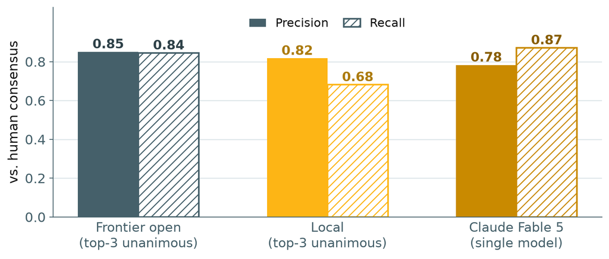

+38%extra labels on the hardest  
question, Claude Fable 5

0.85precision, top-3 frontier-open  
unanimous ensemble

$0fully local  
route

## Key Findings

- 1 command **Code text without leaving Stata.** `catllm classify` turns a string variable into 0/1 indicators ready for `tab` and `regress`; `extract` discovers the categories first, so the codebook comes from the data, not a guess
- 0.85 vs. 0.78 **Run an ensemble with one option.** `consensus("unanimous")` over three diverse models reaches 0.85 precision against 0.78 for Claude Fable 5 and beats it on F1, correcting for over-classification with no hand-merging
- 8 providers **Choose the route your data allows.** One command runs on OpenAI, Anthropic, Google, Mistral, xAI, HuggingFace, Perplexity, or fully local Ollama at $0, where the package auto-starts the server and recovers JSON from small models

## Reproduce This

Everything on this poster runs from one self-contained do-file: no data downloads, no file paths, guarded so it completes with a single API key or with none at all.

```stata
net install catllm, ///
  from("https://raw.githubusercontent.com/chrissoria/cat-llm/main/stata-package/") ///
  replace

catllm setup
do catllm_stata_conference.do
```

The file walks the full pipeline: classify, analyze the resulting indicators, compare three providers, run an ensemble with agreement scores, discover a coding scheme with `extract`, and repeat the whole thing locally at zero cost. Nine further worked examples ship with the package.

github.com/chrissoria/cat-llm · `net install catllm` from the repo (see Reproduce This)

chrissoria@berkeley.edu